# Data Exploration of Tweets

Yuki Nagae

# Data Exploration of Tweets

## Load Dataset

```r
path <- "./python/"
train <- read.delim(paste0(path, "train.tsv"), header = FALSE, sep = " ")
```

```r
train_df <- data_frame(word = train$V1, type = train$V52)
train_df <- train_df %>% mutate(tweet = cumsum(str_detect(word, regex("^BOS"))))
```

## Data Exploration

### Identification of types

[output not shown]

### Identification of summarising properties (histgram, box plot etc)

the count the number of types

```r
train_df %>% count(type, sort=TRUE)
```

```
## # A tibble: 21 × 2
##          type     n
##        <fctr> <int>
## 1           O 25946
## 2    B-person   248
## 3     I-other   186
## 4   B-geo-loc   145
## 5     B-other   128
## 6    I-person   117
## 7   B-company    93
## 8  I-facility    66
## 9  B-facility    61
## 10  B-product    44
## # ... with 11 more rows
```

ggplot for the count of the number of types (very sparse)

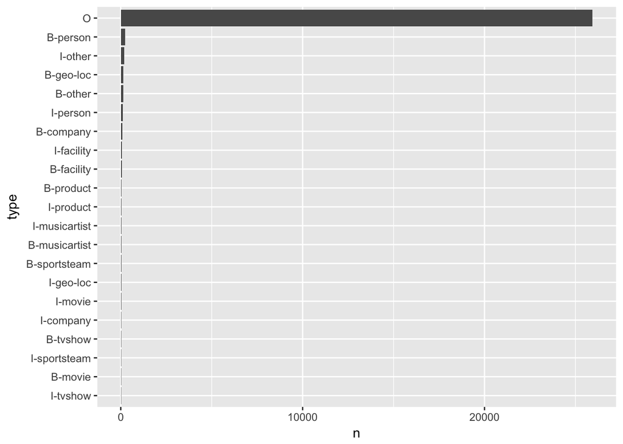

```r
train_df %>% count(type, sort=TRUE) %>%
             mutate(type = reorder(type, n)) %>%
             ggplot(aes(type, n)) + geom_col() + coord_flip()
```

wordcloud visualization

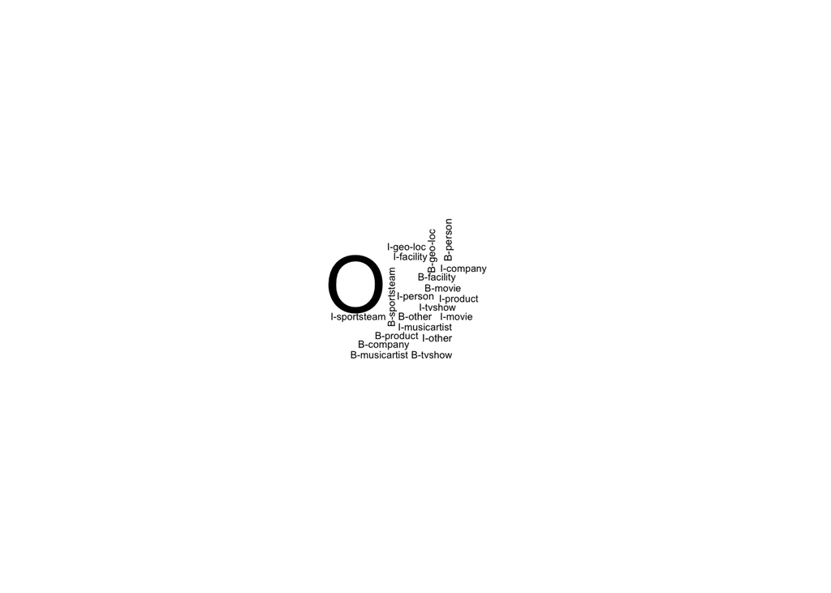

```r
train_df %>% count(type) %>% with(wordcloud(type, n, max.words = 100))
```

### Optional

- how many tweets?

```r
max(train_df$tweet)
```

```
## [1] 1279
```

- how many words for each tweet?

```r
train_df %>% group_by(tweet) %>% summarize(words = n())
```

```
## # A tibble: 1,279 × 2
##    tweet words
##    <int> <int>
## 1      1    14
## 2      2    35
## 3      3    13
## 4      4    29
## 5      5     8
## 6      6    19
## 7      7     8
## 8      8    27
## 9      9    22
## 10    10    18
## # ... with 1,269 more rows
```

```r
summary(train_df %>% group_by(tweet) %>% summarize(words = n()))
```

```
##      tweet            words
##  Min.   :   1.0   Min.   :  2.00
##  1st Qu.: 320.5   1st Qu.: 15.00
##  Median : 640.0   Median : 21.00
##  Mean   : 640.0   Mean   : 21.35
##  3rd Qu.: 959.5   3rd Qu.: 27.00
##  Max.   :1279.0   Max.   :334.00
```

- top 30 words

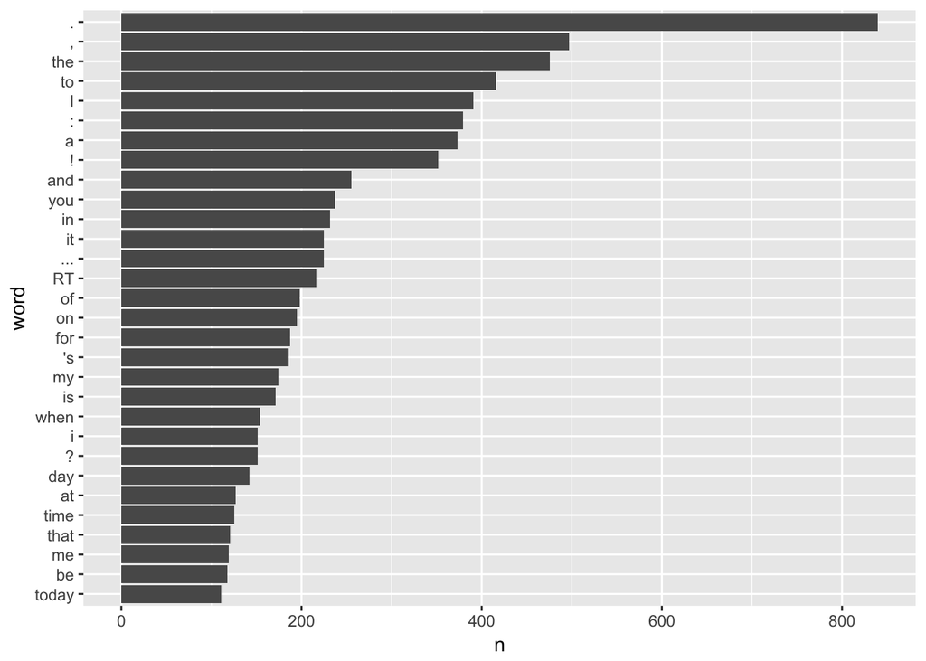

```r
train_df %>% count(word, sort=TRUE) %>%
             filter(word != 'BOS') %>%
             filter(word != 'EOS') %>%
             top_n(30) %>%
             mutate(word = reorder(word, n)) %>%
             ggplot(aes(word, n)) + geom_col() + coord_flip()
```

### (Optional) Identification of

TODO optional

- missing values
- outliers
- clusters
- interesting attributes

## Data Pre-processing

TODO

- lower case (?)
- remove stop words (?)
- separated by BOS ~ EOS (different tweets)
- n-grams (unigram, trigrams and 5-grams)

## Some tasks

TODO maybe not necessary

- noun-phrase chunking
- POS tagging

## Named Entities

TODO we need to define our entities since below are different from the dataset such as B-tvshow => TV show. We can ignore B-tvshow actually.

- Person
  - B-person
  - I-person
- Location
  - B-geo-loc
  - I-geo-loc
- Organization
  - B-company
  - I-company
  - B-facility (optional)
  - I-facility (optional)

## Modeling Techniques

TODO build classifiers

- n-grams + Word2Vec
- n-grams + GloVe
- n-grams + SVM
- n-grams + KNN
- Stanford NLP tool (optional)

### GloVe + SVM + unigram

setup

```r
library(e1071)
library(caret)
```

split data into `train` and `test`

```r
#train$V1 <- NULL
#train_ids <- sample(nrow(train), nrow(train)*0.7)
#svm.train <- train[train_ids,] # 70%
#svm.test <- train[-train_ids,] # 30%
```

SVM model

```r
#svm_model <- svm(V52 ~ ., data=svm.train)
#svm.predict <- predict(svm_model, svm.test)
```

```r
#tr <- train[train_ids,] # 70%
#te <- train[-train_ids,] # 30%

#control <- trainControl(method="cv", number=10)
#metric <- "Accuracy"

#set.seed(7)
#fit.knn <- train(V52 ~ ., data=tr, method="knn", metric=metric, trControl=control)

#lda.predict <- predict(fit.lda, te)
```

confusion matrix

```r
#confusionMatrix(svm.predict, svm.test$V52)
#confusionMatrix(svm.predict, svm.test$V52)
```

write results to a file

```r
#write.table(paste(svm.test$V52, svm.predict, sep = "\t"), file = "glove.wiki.1gram.svm.results", quote = FALSE, row.names = FALSE, col.names = FALSE)
```

## Evaluation

- [MUC-7](http://www-nlpir.nist.gov/related_projects/muc/)

TODO may need evaluation scripts.

- [CoNLL](http://www.cnts.ua.ac.be/conll2002/ner/) - conlleval.pl

```bash
#cat glove.svm.results | tr '\t' ' ' | perl -ne '{chomp;s/\r//g;print $_,"\n";}' | perl connlleval.pl
```

## References

- [Text Mining with R](http://tidytextmining.com)
- GitHub twitter_nlp